# Statistical Analysis Report

Statistics for Operational Excellence

Prepared by: Tshepiso M | Date: September 08, 2026

This report provides a comprehensive analysis of a carwash operational performance enabling strategic improvements and growth opportunities.

## Customer Statistical Analysis

#### Lifetime Value Summary Table

Customer Lifetime Value Statistical Summary

| X | Min. | X1st.Qu. | Median | Mean | X3rd.Qu. | Max. | std | skewness | kurtosis |
| --- | --- | --- | --- | --- | --- | --- | --- | --- | --- |
| 1 | 0 | 600 | 880 | 1191.02 | 1480 | 4480 | 1054.11 | 1.13 | 4.04 |

#### Insights

##### Average Lifetime Value

The average customer lifetime value sits at **1,191.02**, exceeding the median of **880.00**. This tells us that a smaller group of “high value” customers is pulling the average up, while the majority of your customer base generates a lower lifetime value.

This is further proven by standard deviation value of **1054.11**, which informs us that there’s an extreme inequality in customer lifetime values. We can then formulate a hypothesis that our data is right skewed until proven otherwise.

The mean value of **1,191.02** cannot be reliable. We can instead opt for the median to make operational decisions

##### Shape of Distribution

The skewness value resulted to **1.13** while the kurtosis value sits at **4.04**.

This skewness value is over 2 times our benchmark of **0.5**. The statistic proves our hypothesis that our data is positively skewed. On the other hand, the kurtosis value of **4.04** shows the presence of a heavy tail on the right which means extreme values do exist.

#### Confidence Intervals

Customer Lifetime Value confidence interval

| X | mean | lower_bound | upper_bound |
| --- | --- | --- | --- |
| mean of x | 1191.02 | 888.24 | 1493.8 |

Booking Repeat Rate confidence interval

| X | repeat_rate | lower_bound | upper_bound |
| --- | --- | --- | --- |
| p | 0.94 | 0.82 | 0.98 |

#### Insights

##### Lifetime Value Confidence Interval

The shape of the distribution informs us that the data does not follow a normal distribution since it is highly skewed, however, the number of data is greater than 30, **n>30**. This triggers 2 theorems:

**1. Central Limit Theorem:** Sampling distribution of the mean becomes approximately normal, regardless of the original population.

**2. Slutsky’s Theorem:** Sample standard deviation becomes a very accurate, stable estimate of the population standard deviation,σ.

Therefore t-test becomes reliable for our confidence interval calculations

Even the absolute worst-case estimate for the population mean **888.24** is higher than what the typical customer actually spends, **880.00**.

Our typical chosen average lifetime value of **880.00**[median] does not fall within the the calculated confidence interval. This proves that taking “confidence” in the mean is dangerous.

Even at the lowest bound of our confidence interval, we would still be overestimating the lifetime value generated by the majority of customers.

##### Repeat Rate Confidence Interval

Calculated Repeat Rate amounted to **93.9%**. Nearly 94% of customers return for more than one booking. We are therefore 95% Confident that the true Repeat Rate in the interval **[82.1%, 98.4%]**.

Upper bound is close to 100%. We can therefore conclude that **Customer Retention**.Is almost perfect.

## 2. Revenue Statistical Analysis

#### Daily Revenue Trend Analysis

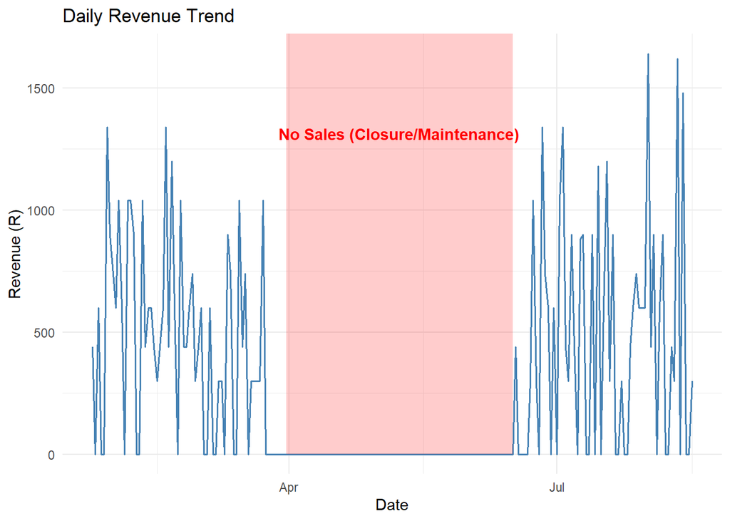

#### Insights

##### 2-Month Revenue Gap Analysis

The business experienced a significant 2-Month Gap in revenue from April to mid June. This period reflects operational downtime due to maintenance and renovations.

### -

### -

#### Revenue Summary Table

Revenue Statistical Summary: All Data

| X | Min. | X1st.Qu. | Median | Mean | X3rd.Qu. | Max. | total_revenue | std | skewness | kurtosis |
| --- | --- | --- | --- | --- | --- | --- | --- | --- | --- | --- |
| 1 | 0 | 0 | 0 | 284.68 | 600 | 1640 | 58360 | 409.23 | 1.3 | 3.72 |

The two-month revenue gap (April–May 2026) was excluded to prevent distortion of average daily revenue and trend analysis. This ensures that all metrics reflect only active trading periods, allowing for accurate performance assessment and a clear quantification of revenue lost during the downtime.

### -

### -

### Active Period Analysis

#### Daily Revenue Trend Analysis (Active Period)

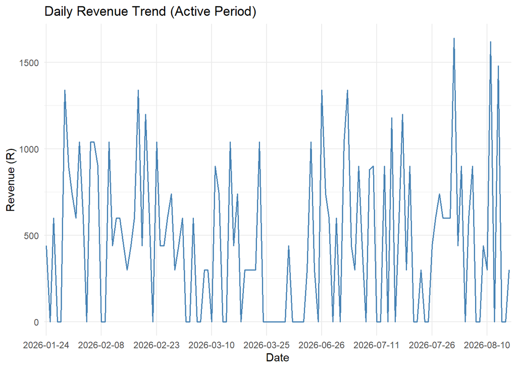

#### Histogram (Active Period)

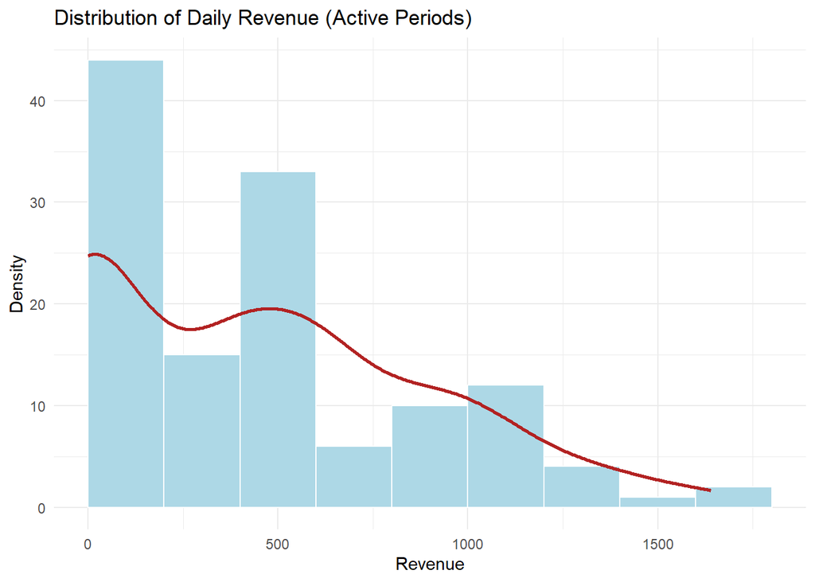

#### Revenue Summary Table (Active period)

Revenue Statistical Summary: Active Period

| X | min | total_revenue | average_revenue | median | sd | max | kurtosis | skweness |
| --- | --- | --- | --- | --- | --- | --- | --- | --- |
| 1 | 0 | 58360 | 459.53 | 440 | 436.07 | 1640 | 2.55 | 0.64 |

#### Insights

##### Comparison Table: Active data vs Active Period

| Metric | All Data | Active Period | Diferrence |
| --- | --- | --- | --- |
| Total Revenue | R58 360 | R58 360 | R0 |
| Mean Daily Revenue | R284.68 | R459.53 | +R174.85 |
| Median Daily Revenue | R0 | R440.00 | +R440.00 |
| Standard Deviation | R409.23 | R436.07 | +R26.84 |
| Skewness | 1.30 | 0.64 | -0.66 |
| Kurtosis | 3.72 | 2.55 | -1.17 |
| Min | R0 | R0 | - |
| Max | R1 640 | R1 640 | - |

##### Remarks

- When excluding the two-month revenue gap (April–May 2026), the average daily revenue increases from **R284.68**. to **R459.53** , 61% increase.
- The distribution also becomes less skewed (skewness **0.64** vs **1.30**)
- And less prone to extreme outliers (kurtosis **2.55** vs **3.72**).
- This confirms that the gap significantly distorted the overall revenue picture, and active-period metrics provide a more accurate baseline for operational performance and loss estimation.
- Statistical tests needs to be conducted in order to verify our confidence in our mean for the active period

##### Loss Calculation

### -

### Normality Assessment (Active Period)

#### Q-Q Plot

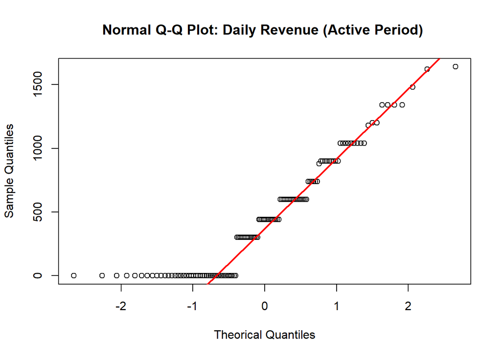

#### Shapiro-Wilk Test

Shapiro-Wilk Test

| X | statistic | p_value |
| --- | --- | --- |
| W | 0.89 | < 0.001 |

#### Insights

##### Normality Remark: Q-Q Plot

- Portion of theorical quantiles, **-2.8 < X < -0.4** lies flat at a sample quantile of 0. This indicates a high concentration of zero-revenue days
- While the middle-to-upper values roughly follow the reference line, the far right end curves slightly below the line, indicating a light upper tail relative to a normal distribution.

##### Sapiro-Wilk Test

- **P-Value < 0.05**. Hypothesis for Normality is rejected, and we can therefore conclude that our data does not follow normality.
- However, our data, **n > 100**, the Central Limit Theorem Applies. We can conclude that our sample statistic, mean approximates a normal distribution regardless of the intial distribution. Parametric Tests are eligible.

### -

#### Average daily CI revenue (Active Period)

Average Daily revenue (Active Period): Confidence Interval

| X | mean | lower_bound | upper_bound |
| --- | --- | --- | --- |
| mean of x | 459.53 | 382.95 | 536.1 |

#### Revenue Loss Summary(Over Non-Active Period)

Revenue Loss Summary Over the Non-Active Period

| X | Metric | Value |
| --- | --- | --- |
| 1 | Active Days | 127 |
| 2 | Gap Days | 78 |
| 3 | Mean Daily Revenue (Active) | 459.528 |
| 4 | Median Daily Revenue (Active) | 440 |
| 5 | Estimated Loss (Mean-Based) | 35843.15 |
| 6 | Estimated Loss (Median-Based) | 34320 |
| 7 | 95% CI for Loss (Mean-Based) | R29870.235 – R41816.06 |

#### Insights

##### Revenue Loss Summary

- Based on the active-period performance, **n=127 days** , the estimated revenue lost during the **n=78 day period** is **R35843.15** (median-based:R34320). The 95% confidence interval for the loss ranges from R29870.235 to R41816.06.

### -

### Weekdays’ Revenue vs Weekends’ Revenue

#### Weekdays vs Weekends (Active Period)

Weekdays’ Revenue vs Weekends’ Revenue

| X | Metric | Value |
| --- | --- | --- |
| 1 | weekday_mean | 503.596 |
| 2 | weekend_mean | 356.316 |
| 3 | null_hypotheis | True difference in means between group weekday and group weekend is equal to 0 |
| 4 | alt_hypothesis | True difference in means between group weekday and group weekend is greater than 0 |
| 5 | p_value | 0.0321215396889338 |

#### Insights

##### Weekdays vs Weekends (Active Period)

The results show that weekdays generate significantly higher revenue compared to weekends. With a p-value, **p = 0.032.**, the null hypothesis is rejected.This suggests that the business relies more heavily on weekday activity, presenting an opportunity to boost weekend performance through targeted promotions or service offerings.

### Revenue Comparison Across Weeks

#### Comparison Test

Revenue Comparison Across Weeks

| X | Df | Sum.Sq | Mean.Sq | F.value | Pr..F. |
| --- | --- | --- | --- | --- | --- |
| factor(week) | 19 | 4336806 | 228252.9 | 1.24 | 0.24 |
| Residuals | 107 | 19622766 | 183390.3 | NA | NA |

#### Insights

##### Revenue Comparison Across Weeks

The results showed no statistically significant difference in revenue across weeks. We are accepting the null hypothesis of no difference with **F(19, 107) = 1.245**, **P =0.237** .This indicates that revenue performance remained relatively stable throughout the active trading period, with no single week outperforming or under-performing the others significantly.

### Booking-Service Intelligence

#### Completion-Rate Summary

Completion Rate Confidence Summary by Service

| X | service_id | total | completed | rate | lower_ci | upper |
| --- | --- | --- | --- | --- | --- | --- |
| 1 | 1 | 145 | 100 | 68.97 | 60.67 | 76.24 |
| 2 | 2 | 131 | 88 | 67.18 | 58.35 | 74.97 |
| 3 | 3 | 125 | 80 | 64.00 | 54.88 | 72.25 |

#### Completion Rates Comparison

Completion Rates Comparison

| X | test | x_squared | df | p_value |
| --- | --- | --- | --- | --- |
| X-squared | Chi-Square | 1.01 | 4 | 0.91 |

#### Insights

##### Completion Rate Confidence Summary by Service

- Service 1 performs best among the three, with a completion rate of **69%**
- Service 3 performs worst with a completion rate of **64%**, however, the gap is relatively small.
- All CI’s overlap. We therefore can conclude that there’s minimal practical difference between the completion rates.

##### Completion Rates Comparison

The P-Value indicates a value of **0.91**, which is significantly high than the significance level. We therefore accept the null hypothesis that the there is no significance difference between the completion rates.

### Payment Intelligence

#### Average Payment Delay

Average Time Difference Between Scheduled and Payment Date

| X | x |
| --- | --- |
| 1 | 74.93 |

#### Payment Timing Patterns

payment Timing Patterns

| X | day_type | payment_count | avg_amount | total_revenue |
| --- | --- | --- | --- | --- |
| 1 | weekday | 202 | 221.88 | 44820 |
| 2 | weekend | 66 | 205.15 | 13540 |

#### Weekday vs Weekend Revenue

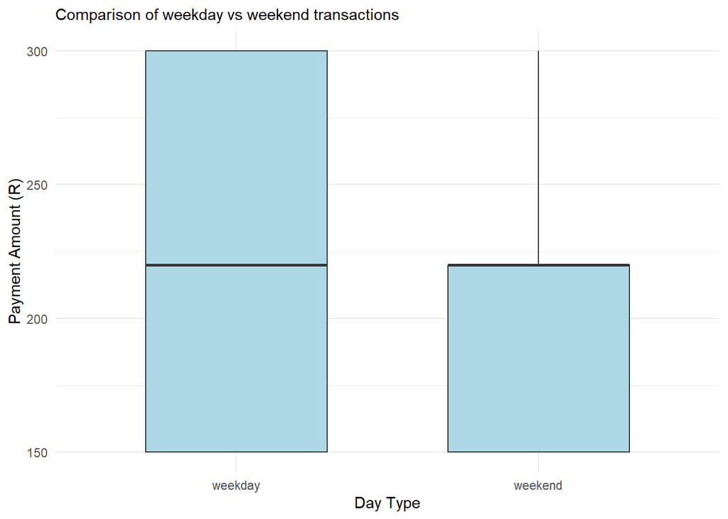

#### Insights

##### Average Payment Delay

Customers take **2.5 months** to pay after booking on average. This is concerning as it can be a cause of cash flow strains and high risk. It also indicates poor collections process. This can be due to the business offering credit terms and allow customers to pay late.